# Police Militarization, State Crime, and the Use of Lethal Force

## Introduction

Over the past year, one dramatic event which stands out is the outpouring of support for the Black Lives Matter movement and its calls to "defund the police." In specific, one possible problem with police funding is the increased militarization of the American police force. Militarization is the process of moving towards a more militaristic state, through programs such as the [1033 program](https://apps.dtic.mil/sti/pdfs/ADA609611.pdf) of the National Defense Authorization Act, which allow the Department of Defence to transfer military weapons to local police forces to deter drug crime.

## Background

The history of police militarization is rooted in the history of the American "war on drugs." In the 90's the federal government passed the [1991 NDAA](https://www.govtrack.us/congress/bills/101/hr2461/text). This contained, in its section 1208, the policy that, with the right authorization, the military could transfer its excess equipment to law enforcement, which came to be known as the "1208 program." In 1997, this was expanded under the "[1033 program](https://apps.dtic.mil/sti/pdfs/ADA609611.pdf)," which relaxed the bar for authorization and increased the transfer of weapons in order to prevent drug crime.

Arguments for and against militarization are varied. Proponents claim that it is the natural response to the escalating danger of drug-related crime (see documents above), slows down crime, and keeps officers safe. Arguments against the militarization include the idea that officers dressed in combat gear leads to unrest in otherwise stable situations, and the claim that having access to such hardware makes police over-aggressive, resulting in unnecessary uses of lethal force ([see Steidley et al., sections 2 and 3 for more info](https://onlinelibrary.wiley.com/doi/full/10.1111/soc4.12674?casa_token=hGOq_J7fQ4oAAAAA%3Anl9UFTAEvia63GFo4IsszioZnr1ZxT65Q-BKvspyBYDGinAdON5PPk3wNG46syOK0xzU2D_4COd1Bo6h)). This has led to those who are cynical of police forces to [point to militarization as problem](https://journals.sagepub.com/doi/full/10.1177/0011128718770689?casa_token=lCpAMYd_XGAAAAAA%3A-fEebmBACaGZk6oNqc6vE-Mezj-d7p_rKRpR39jui-7eC1UPZDDSb4KbQ0KBxY-Acoz9nWjJuCbl1w). Reforming such a problem or proving that it isn't a problem in the first place could be beneficial to relations between the police and the public. In this analysis, I will specifically focus on the ideas that increased militarization leads to decreased violent crime, and the counterargument that it causes unnecessary casualties.

## Project Setup and Methodology

Other analyses ([for example, Delehanty et al.](https://journals.sagepub.com/doi/full/10.1177/2053168017712885)) have confirmed a link between police militarization and violence in single states. I want to do a national analysis of the outcomes of police militarization composed of 3 parts:

1. The rate of lethal force employed by US police forces over time
2. The change over time in the rate of crime
3. The militarization of american police forces

The idea here is to see if the policy of police adopting military hardware is an effective means of maintaining a safe and just society. The primary metrics used are the number of violent crimes committed, the number of incidents of lethal force, and the dollar value of the military hardware transferred to state police departments.

This study is limited to violent crimes because the language surrounding the transfer of military property specifically references drug-related crime, which typically refers to violent crimes (see SEC.1208 (a) of [The 1991 National Defense Authorization Act](https://www.govtrack.us/congress/bills/101/hr2461/text) or page 1 of [The 1033 program](https://apps.dtic.mil/sti/pdfs/ADA609611.pdf)). This dataset will come from [Kaggle](https://www.kaggle.com/marshallproject/crime-rates). Kaggle is a community of data scientists who share datasets. The dataset tracks different types of crime dating back to 1975. For this study, I will only use the violent crime statistics.

The reason to study incidents of lethal force instead of all police violence is the severity of lethal force. The difference between killing someone and injuring them is that death is permanent and irreversible whereas other impacts are likely impermanent, and thus lower stakes. Studying deaths should give insight as to how high-pressure situations are being shaped by the equipment in use. The dataset I will be using comes from [fatalencounters.org](https://fatalencounters.org/), a comprehensive database containing all deaths involving a police officer dating back to 2000, as well as large quantities of data regarding each death. For this study, I will only use the instances of deaths and when they occured. Note that this takes into account all police killings, not just those which happend with military equipment. The reason for this is that [one anti-militarization theory](https://onlinelibrary.wiley.com/doi/full/10.1111/soc4.12674?casa_token=hGOq_J7fQ4oAAAAA%3Anl9UFTAEvia63GFo4IsszioZnr1ZxT65Q-BKvspyBYDGinAdON5PPk3wNG46syOK0xzU2D_4COd1Bo6h) is that it causes an increase in aggression which may manifest in other ways and lead to killings. The goal is to limit overall deaths, so all deaths are taken into account.

Studying the dollar value of the military hardware gives an understanding of the degree of militarization of a police force. The higher dollar value transferred, the more military equipment a police department acquires, the more militarized it becomes. The dataset I will be using comes from [The Washington Post](https://github.com/washingtonpost/data-1033-program/blob/master/1033.csv), who obtained it via a Freedom of Information Act request. The set includes all transfers dating back to 1991, the equipment transferred, the cost, etc. For this study, I will only use the total cost of each transfer summed together for each year.

The analysis takes place on data from the years 2000-2014, because those are the years for which data regarding all 3 metrics overlaps. This also takes place on a national level as opposed to a state-by-state breakdown. This is because I am not looking to compare different states against each other, but am exclusively looking at the variables identified above and how they change over time. Using all the states together hopefully improves the precision relative to any individual state due to having vastly more total data points.

## Ethics

The ethical concerns relating to this problem are considerable. First, this is a situation with life-or-death consequences, and one in which there are a large number of variables which are constantly changing. Even if I maximized the utility of the few data sets which I can find, it would only provide some context into the problem, and would not be enough to make any sweeping generalizations as to solutions to the complicated issue of police violence. Secondly, it is very hard to quantify "police militarization", which is more of a sociological term than a scientific one. Due to the difficulty of making sociological generalizations, I will need to be very careful in order to not pretend like this has definitive answers about the justice system one way or another. This analysis will be exclusively for generating an idea of whether or not there is a glaring statistical correlation between militarization, crime, and civilian deaths, and is not in depth enough to make any more nuanced point about such a complex system.

The societal impacts of this problem are sweeping. Inaccurately assessing the threat posed by militarized police forces or the benefit reaped by the same could lead to a needless increase and civilian deaths when interacting with the police, or alternatively could lead to reversing a trend in decreasing crime. This is further stressed by the politically charged nature of this situation, as police forces nationwide want to show that their operation does not cause unnecessary harm and activists for police reform want to show that this program is a major cause of needless violence. Inaccurate information could also have a ripple effect throughout the rest of American society, as failing to reform the problems associated with police violence could inflame the [already fraught tensions](https://www.cambridge.org/core/journals/perspectives-on-politics/article/black-lives-matter-evidence-that-policecaused-deaths-predict-protest-activity/BFA2E74F4BCB25C3C222807E8B1111D4) between certain police forces and the people who they pledged to protect.

## Research Questions

1. How has the use of lethal force by the police changed over time?
2. How has the crime rate changed over time?
3. Has the increase in funding for military weapons and training correlated with a change in either of these trends?

```python
import pandas as pd
from scipy import stats
import matplotlib.pyplot as plt

#Lethal Force Frame
LFF = pd.read_csv("data/LethalForceSpreadsheet.csv")
#Military Transfer Frame
MTF = pd.read_csv("data/MilitaryTranferSpreadsheet.csv")
#State Crime Frame
SCF = pd.read_csv("data/StateCrimeSpreadsheet.csv")
```

## Preparing Datasets

Up first is the national number of police-caused deaths for each year

```python
LFF = LFF.loc[:,['Date of injury resulting in death (month/day/year)']]
LFF = LFF.rename(columns = {"Date of injury resulting in death (month/day/year)" : "Year"})
LFF['Year'] = LFF['Year'].str[-4:]
LFF['Year'] = LFF['Year'].astype(int)
LFF = LFF[LFF.Year>=2000]
LFF = LFF[LFF.Year<=2014]
LFF = LFF.Year.value_counts().to_frame()
LFF = LFF.reset_index()
LFF = LFF.rename(columns = {"Year":"Deaths" })
LFF = LFF.rename(columns = {"index":"Year" })
LFF = LFF.sort_values("Year")
```

Next is the national number of violent crimes for each year

```python
SCF = SCF.loc[:,['report_year', 'violent_crimes']]
SCF = SCF.rename(columns = {"report_year" : "Year", "violent_crimes" : "Crimes"})
SCF = SCF[SCF.Year>=2000]
SCF = SCF[SCF.Year<=2014]
SCF = SCF.groupby('Year', as_index = False).sum()
```

Last is the level of militarization, measured by the annual dollar value of military equipment transffered from the Department of Defense to local Law Enforcement Agencies

```python
MTF = MTF.loc[:,['Cost', 'Ship Date']]
MTF['Ship Date'] = MTF['Ship Date'].str[-4:]
MTF['Ship Date'] = MTF['Ship Date'].astype(int)
MTF = MTF.rename(columns = {"Ship Date" : "Year"})
MTF = MTF[MTF.Year>=2000]
MTF = MTF[MTF.Year<=2014]
MTF = MTF.groupby('Year', as_index = False).sum()
```

## Visualizing Data

Before answering the research questions, visualizing how these variables change over the given time frame may help build some intuition about this data

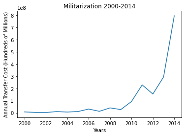

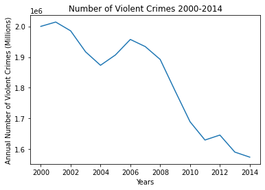

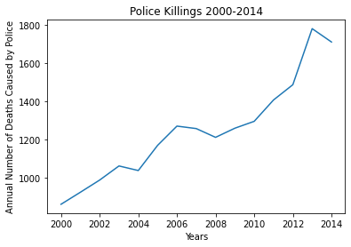

```python
x = MTF["Year"]
y = MTF["Cost"]

plt.title('Militarization 2000-2014')
plt.xlabel('Years')
plt.ylabel('Annual Transfer Cost (Hundreds of Millions)')

plt.plot(x,y)
plt.show()

x = SCF["Year"]
y = SCF["Crimes"]

plt.title('Number of Violent Crimes 2000-2014')
plt.xlabel('Years')
plt.ylabel('Annual Number of Violent Crimes (Millions)')

plt.plot(x,y)
plt.show()

x = LFF["Year"]
y = LFF["Deaths"]

plt.title('Police Killings 2000-2014')
plt.xlabel('Years')
plt.ylabel('Annual Number of Deaths Caused by Police')

plt.plot(x,y)
plt.show()
```

In order to get a better sense of how the variables change with each other, I have superimposed their relative change onto the following graph. Note that the y axis here is not shown because they are all different variables, and this is simply meant to show relative change.

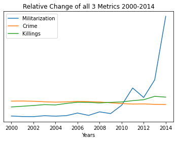

```python
x = MTF["Year"]
y = MTF["Cost"]/MTF["Cost"].mean()
x2 = SCF["Year"]
y2 = SCF["Crimes"]/SCF["Crimes"].mean()
x3 = LFF["Year"]
y3 = LFF["Deaths"]/LFF["Deaths"].mean()

plt.xlabel("Years")
plt.title("Relative Change of all 3 Metrics 2000-2014")
plt.plot(x,y,label="Militarization")
plt.plot(x2,y2,label="Crime")
plt.plot(x3,y3,label="Killings")
plt.legend()
plt.tick_params(axis = 'y', which = 'both', left = False, labelleft = False)
plt.show()
```

## Answering Research Question 1

How has the use of lethal force by the police changed over time?

```python
LFF2 = pd.read_csv("data/LethalForceSpreadsheet.csv")
LFF2 = LFF2.loc[:,['Date of injury resulting in death (month/day/year)']]
LFF2 = LFF2.rename(columns = {"Date of injury resulting in death (month/day/year)" : "Year"})
LFF2['Year'] = LFF2['Year'].str[-4:]
LFF2['Year'] = LFF2['Year'].astype(int)
LFF2 = LFF2.Year.value_counts().to_frame()
LFF2 = LFF2.reset_index()
LFF2 = LFF2.rename(columns = {"Year":"Deaths" })
LFF2 = LFF2.rename(columns = {"index":"Year" })
LFF2 = LFF2.sort_values("Year")
LFF2 = LFF2[LFF2.Year>=2000]
LFF2 = LFF2[LFF2.Year<=2020]
```

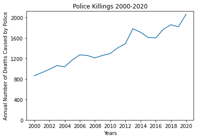

```python
x = LFF2["Year"]
y = LFF2["Deaths"]

plt.title('Police Killings 2000-2020')
plt.xlabel('Years')
plt.ylabel('Annual Number of Deaths Caused by Police')

plt.plot(x,y)
plt.xticks(range(2000, 2021, 2))
plt.yticks(range(0, 2200, 400))
plt.show()
```

The above graph seems to show a steady upward trend. To confirm if this is the case, here is a pearson's r test measuring how if the number of deaths is correlated with time.

```python
stats.pearsonr(LFF2["Deaths"], LFF2["Year"])
```

```
(0.9708353382237427, 3.046295545058456e-13)
```

With a p-value<0.05 and a high value for correlation, the upward trend in police killings relative to time seems significant. Note, however, that this is not data stretching back before the creation of the 1033 program, so it can't be determined if this is a new trend or the continuation of an existing one.

## Answering Research Question 2

How has the crime rate changed over time?

```python
SCF2 = pd.read_csv("data/StateCrimeSpreadsheet.csv")
SCF2 = SCF2.loc[:,['report_year', 'violent_crimes']]
SCF2 = SCF2.rename(columns = {"report_year" : "Year", "violent_crimes" : "Crimes"})
SCF2 = SCF2.groupby('Year', as_index = False).sum()
```

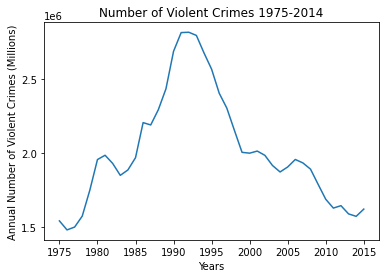

```python
x = SCF2["Year"]
y = SCF2["Crimes"]

plt.title('Number of Violent Crimes 1975-2014')
plt.xlabel('Years')
plt.ylabel('Annual Number of Violent Crimes (Millions)')

plt.yticks(range(0, 3000000, 500000))
plt.plot(x,y)
plt.show()
```

This seems to show that the crime rate peaked in the 90's and has fallen since then. This begs a new question: did this reversal happen as a result of instituting the 1033 program?

```python
Post1033 = SCF2[SCF2.Year>=1997]
Pre1033 = SCF2[SCF2.Year<=1997]
```

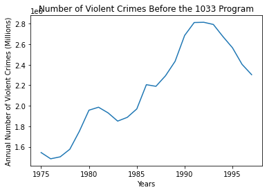

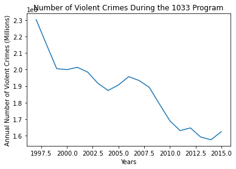

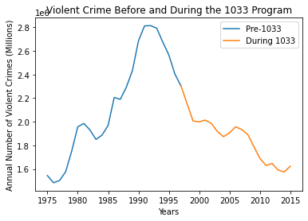

```python
x = Pre1033["Year"]
y = Pre1033["Crimes"]

plt.title('Number of Violent Crimes Before the 1033 Program')
plt.xlabel('Years')
plt.ylabel('Annual Number of Violent Crimes (Millions)')

plt.plot(x,y)
plt.show()

x = Post1033["Year"]
y = Post1033["Crimes"]

plt.title('Number of Violent Crimes During the 1033 Program')
plt.xlabel('Years')
plt.ylabel('Annual Number of Violent Crimes (Millions)')

plt.plot(x,y)
plt.show()

x = Pre1033["Year"]
y = Pre1033["Crimes"]
x2 = Post1033["Year"]
y2 = Post1033["Crimes"]

plt.xlabel("Years")
plt.ylabel("Annual Number of Violent Crimes (Millions)")
plt.title("Violent Crime Before and During the 1033 Program")
plt.plot(x,y,label="Pre-1033")
plt.plot(x2,y2,label="During 1033")
plt.legend()
plt.show()
```

The above graphs, from top to bottom, show (1) the number of violent crimes before the 1033 program, (2) the number of violent crimes during the 1033 program, and (3) a merged graph of the 2. As can be seen on the third graph, it seems that the downward trend in crime since instituting the program is a continuation of a crime rate which was already falling. Let's zoom in on that part:

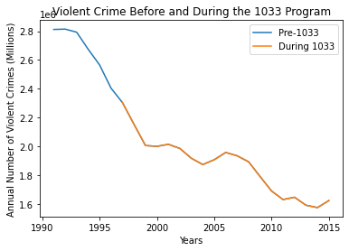

```python
Post1033 = SCF2[SCF2.Year>=1997]
Pre1033 = SCF2[SCF2.Year<=1997]
Pre1033 = SCF2[SCF2.Year>=1991]

x = Pre1033["Year"]
y = Pre1033["Crimes"]
x2 = Post1033["Year"]
y2 = Post1033["Crimes"]

plt.xlabel("Years")
plt.ylabel("Annual Number of Violent Crimes (Millions)")
plt.title("Violent Crime Before and During the 1033 Program")
plt.plot(x,y,label="Pre-1033")
plt.plot(x2,y2,label="During 1033")
plt.legend()
plt.show()
```

This answers the previous question by seemingly showing that the 1997 creation of the 1033 program was not, by itself, the cause for a significant change in trajectory of the violent crime rate, but an extension of the fall that had already begun in 1991. To make sure of this, I ran tests measuring the correlation of both of these sets with time.

```python
stats.pearsonr(Pre1033["Crimes"], Pre1033["Year"])
```

```
(-0.9438789638122997, 1.4927193302739846e-12)
```

```python
stats.pearsonr(Post1033["Crimes"], Post1033["Year"])
```

```
(-0.94372258752651, 1.3612923475724907e-09)
```

While the 1033 program did not seem to change the trajectory of violent crime by itself, it would be premature to write off the impact of all police militarization as riding a previously existing downward trend in violent crime. Specifically, note that the [NDAA for 1991](https://www.govtrack.us/congress/bills/101/hr2461/text) (see section 1208) contained the precursor for the 1033 program, which is a possible explanation for the decrease in crime starting that year, and thus validating the transfer of small arms as a viable means of combating crime. This brings up another question: if we expand the scope of "police militarization" to include all Department of Defense transfers, not just those under the 1033 program but also under its precursor, the 1208 program, does the data show a difference between the pre-transfer and post-transfer crime rate?

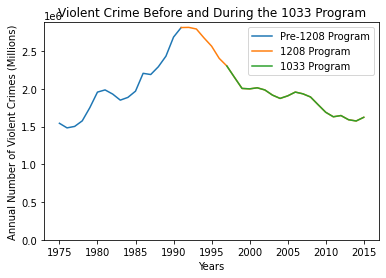

```python
During1033 = SCF2[SCF2.Year>=1997]
During1208 = SCF2[SCF2.Year<=1997]
During1208 = SCF2[SCF2.Year>=1991]
Pre1208 = SCF2[SCF2.Year<=1991]


x = Pre1208["Year"]
y = Pre1208["Crimes"]
x2 = During1208["Year"]
y2 = During1208["Crimes"]
x3 = During1033["Year"]
y3 = During1033["Crimes"]

plt.xlabel("Years")
plt.ylabel("Annual Number of Violent Crimes (Millions)")
plt.title("Violent Crime Before and During the 1033 Program")
plt.plot(x,y,label="Pre-1208 Program")
plt.plot(x2,y2,label="1208 Program")
plt.plot(x3,y3,label="1033 Program")
plt.yticks(range(0, 3000000, 500000))
plt.legend()
plt.show()
```

Including the 1208 program seems to provide a much stronger case for militarization stopping violent crime, as evidenced by the obvious downward shift in crime through its duration and into the duration of the 1033 program. If the 1208 program is counted alongside the 1033 program, any correlation between militarization and the violent crime rate cannot be written off as continuing a previous trend. This begs a new question: Is it warranted to classify the 1208 program as a legitimate force on the level of the 1033 program despite its limited scope?

The 1208 program was more stringent in how equipment was to be approved to be transferred, so it might not be accurate to consider it a force contributing to militarization at the same level as the 1033 program. If the 1208 program transfers were negligable, it would prove that the downward shift in 1991 was caused by some other factor. If not, it would still be possible that militarization programs were responsible for decreasing crime. In order to measure the difference, let's look at the total cost of transfers per year from 1991 (the start of the 1208 program) to the present day.

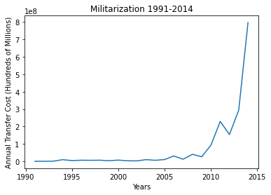

```python
MTF2 = pd.read_csv("data/MilitaryTranferSpreadsheet.csv")
MTF2 = MTF2.loc[:,['Cost', 'Ship Date']]
MTF2['Ship Date'] = MTF2['Ship Date'].str[-4:]
MTF2['Ship Date'] = MTF2['Ship Date'].astype(int)
MTF2 = MTF2.rename(columns = {"Ship Date" : "Year"})
MTF2 = MTF2[MTF2.Year<=2014]
MTF2 = MTF2.groupby('Year', as_index = False).sum()
MTF2.head()

x = MTF2["Year"]
y = MTF2["Cost"]

plt.title('Militarization 1991-2014')
plt.xlabel('Years')
plt.ylabel('Annual Transfer Cost (Hundreds of Millions)')

plt.plot(x,y)
plt.show()
```

In looking for a difference between the levels of militarization under the 1208 program and the 1033 program, there doesn't appear to be a significant difference between the years of 1991-1997 and 1997-2005. The major feature of this graph is the drastic increase in transfers from the late 2000's onwards, but this happens well after the start of the 1033 program. For the purposes of determining if the negative correlation between militarization and crime levels should be disqualified based on being part of a previous trend, this graph shows that the years of 1991-1997 should not be treated as categorically different from 1997 onwards. This means that it is possible that the downward shift seen in violent crime starting in 1991 is a product of the 1208 and 1033 programs.

## Answering Research Question 3

Has the increase in funding for military equipment correlated with a change in either of these trends?

```python
CrimeCorr = stats.pearsonr(MTF["Cost"], SCF["Crimes"])
DeathsCorr = stats.pearsonr(MTF["Cost"], LFF["Deaths"])
print("The correlation between the annual amount of military equipment transferred and state crime rate is:", CrimeCorr)
print("The correlation between the annual amount of military equipment transferred and rate of lethal force is", DeathsCorr)
```

```
The correlation between the annual amount of military equipment transferred and state crime rate is: (-0.7433680761523075, 0.0014921185209890435)
The correlation between the annual amount of military equipment transferred and rate of lethal force is (0.7614336024642523, 0.000973761918409527)
```

Due to having a p-value<0.05 and high values of correlation, the tests show that the increase in the amount of military equipment transferred over time is correlated with both a significant decrease in the crime rate and a significant increase in the number of police uses of lethal force.

## Discussion

Fundamentally, this analysis was supposed to create a better understanding of whether or not the police system in America needs to be changed to reflect the dangers of increased militarization. While it does seem that the answer to question 3 proves that increased militarization correlates with a decrease in crime an increase in the use of lethal force, I do not believe that this study proves a causal relationship strong enough to make prescriptive statements about changing the police system in America one way or another.

This may seem to suggest that "I can't say for sure that police militarization causes increased killings, but question 2 indicates that it likely causes a decrease in crime. Police militarization is thus justified." I vehemently disagree with this logic. Recall that the arguments for and against militarization are varied. Even if this study proved that the relationship between militarization crime is a causal one (which, as previously specified, it does not), proponents of these programs would still have to contend with the psychological anguish caused by marching around supposedly peaceful cities with military equipment, the impact of which is much tougher to quantify. In order to actually justify the continued existance of the 1033 program, I would need to find more data to point to the idea that police militarization is specifically accomplishing its goal of ending the threat of drug crime, or that it has negligable pysocological effects on both the police and the community at large.

I thus assert that this study has accomplished its goal of providing a better understanding as to the correlation between police militarization, violent crime, and police killings, but is inconclusive as to the normative judgement of whether or not these trends definitively warrant change. With a better understanding of how these factors have changed over time, each of us individually has to make a decision about what we think justice looks like, and how much risk we are willing to take in order to bring about that justice.

## Links to Works Used

Substantive data set describing the use of police violence over the past 20 years [Lethal force dataset](https://docs.google.com/spreadsheets/d/1dKmaV_JiWcG8XBoRgP8b4e9Eopkpgt7FL7nyspvzAsE/edit#gid=0)

National crime rate data seta [Violent crime dataset](https://www.kaggle.com/marshallproject/crime-rates)

Dataset of transfers of military equipment from 1991-2015 [Militarization data set](https://github.com/washingtonpost/data-1033-program/blob/master/1033.csv)

Individual study on militarization vs violence in Nevada [Delehanty et al.](https://journals.sagepub.com/doi/full/10.1177/2053168017712885)

Congressional report on 1033 program [1033 program](https://apps.dtic.mil/sti/pdfs/ADA609611.pdf)

Text of the 1991 National Defense Authorization Act [1991 NDAA](https://www.govtrack.us/congress/bills/101/hr2461/text)

Study showing that protests are caused by higher rates of police violence [Cambridge](https://www.cambridge.org/core/journals/perspectives-on-politics/article/black-lives-matter-evidence-that-policecaused-deaths-predict-protest-activity/BFA2E74F4BCB25C3C222807E8B1111D4)

**You will need university login for these 2:**

Study describing militarization and its impacts [Steidley et al.](https://onlinelibrary.wiley.com/doi/full/10.1111/soc4.12674?casa_token=hGOq_J7fQ4oAAAAA%3Anl9UFTAEvia63GFo4IsszioZnr1ZxT65Q-BKvspyBYDGinAdON5PPk3wNG46syOK0xzU2D_4COd1Bo6h)

Study reviewing how police and civilians feel about militarization [Surveys](https://journals.sagepub.com/doi/full/10.1177/0011128718770689?casa_token=lCpAMYd_XGAAAAAA%3A-fEebmBACaGZk6oNqc6vE-Mezj-d7p_rKRpR39jui-7eC1UPZDDSb4KbQ0KBxY-Acoz9nWjJuCbl1w)